# Sheet 8

Mit Claus Sarnighausen (06), Mika Holzem (01) und Konstantin Scheffold

```python
import os
import numpy as np
import torch
from torch import nn
from matplotlib import pyplot as plt
```

## 1) Anomaly detection for Autoencoders

```python
# load processed data from sheet 6!
y_train = np.load('..\..\sheet06_data\y_train_short.npy')
y_val = np.load('..\..\sheet06_data\y_val_short.npy')
y_test = np.load('..\..\sheet06_data\y_test_short.npy')

z_train = np.load('..\..\sheet06_data\z_train.npy')
z_val = np.load('..\..\sheet06_data\z_val.npy')
z_test = np.load('..\..\sheet06_data\z_test.npy')
```

(a)

```python
device = "cuda" if torch.cuda.is_available() else "cpu"
print(f"Using {device} device")
```

```
Using cuda device
```

```python
# TODO: Construct autoencoder
class autoencoder(nn.Module):

    def __init__(self, hidden_dim= 400, bottleneck_dim=10, img_sz=40):
        super().__init__()
        flatten = nn.Flatten()
        encode1 = nn.Linear(img_sz**2, hidden_dim, bias=True)
        encode2 = nn.Linear(hidden_dim, bottleneck_dim, bias=True)
        decode1 = nn.Linear(bottleneck_dim, hidden_dim, bias=True)
        decode2 = nn.Linear(hidden_dim, img_sz**2, bias=True)
        unflatten = nn.Unflatten(1, (1,40,40))


        # define encoder and decoder in seperate methods
        self.encoder = nn.Sequential(
            flatten, # 1600
            encode1, # hidden dim
            nn.ReLU(),
            encode2, # bottleneck dim
            nn.ReLU()
            )

        self.decoder = nn.Sequential(
            decode1, # bottleneck dim
            nn.ReLU(),
            decode2, # hidden dim
            )

    def forward(self, x):
        encoded = self.encoder(x)
        decoded = self.decoder(encoded)
        decoded = nn.functional.normalize(decoded, p=1)

        return nn.Unflatten(1, (1,40,40))(decoded)
```

This simple autoencoder is built from an encoder and a decoder with a single hidden layer each. The decoder performs exactly the revcerse operation

(b)

```python
# TODO: Train autoencoder on QCD jets
# Choose the bottleneck dimension between 5 and 20
```

```python
# set up training data & dataloader for QCD jets only
class ae_data( torch.utils.data.Dataset ):

    def __init__( self, imgs, labels, qcd=True, top=False ):
        self.labels = labels

        # depending on input QCD, top or both are returned
        if qcd and not top:
            self.imgs = imgs[ labels == 0 ]
        elif top and not qcd:
            self.imgs = imgs[ labels == 1 ]
        elif qcd and top:
            self.imgs = imgs
        self.imgs = torch.Tensor(self.imgs).float()


    def __len__(self):
        return self.imgs.shape[0]

    def __getitem__(self, idx):
        return self.imgs[idx]

# load QCD only
train_dataset = ae_data(z_train, y_train, qcd=True, top=False)
test_dataset = ae_data(z_test, y_test, qcd=True, top=False)
val_dataset = ae_data(z_val, y_val, qcd=True, top=False)

trn_dataloader = torch.utils.data.DataLoader(train_dataset, batch_size=64, shuffle=True )
tst_dataloader = torch.utils.data.DataLoader(test_dataset, batch_size=64, shuffle=False )
val_dataloader = torch.utils.data.DataLoader(val_dataset, batch_size=64, shuffle=False )
```

```python
def batch_loss(model, loss_fn, x):
    x = x.to(device)
    pred = model(x)
    loss = loss_fn(pred, x)
    return loss
```

```python
def train_epoch(model, dataloader, loss_fn, losses, batch_loss_fn):
    for x in dataloader:
        optimizer.zero_grad()

        loss = batch_loss_fn(model, loss_fn, x)
        loss.backward()
        optimizer.step()
        losses.append(loss.item())
    return losses
```

```python
def val_epoch(model, dataloader, loss_fn, losses, batch_loss_fn):
    losses_epoch = []
    with torch.no_grad():
        for x in dataloader:
            loss = batch_loss_fn(model, loss_fn, x)
            losses_epoch.append(loss.item())
    losses.append(np.mean(losses_epoch))
    return losses
```

```python
n_epochs = 200
bottleneck_dim = 20
loss_fn = nn.MSELoss()

model = autoencoder(bottleneck_dim=bottleneck_dim).to(device)
print(model)
total_parameters = sum(p.numel() for p in model.parameters() if p.requires_grad)
print(f"Model has {total_parameters:d} trainable parameters")

learning_rate = 1e-3
optimizer = torch.optim.Adam(model.parameters(), lr=learning_rate)
train_losses = []
val_losses = []
for epoch in range(n_epochs):
    train_losses = train_epoch(model, trn_dataloader, loss_fn, train_losses, batch_loss)

    val_losses = val_epoch(model, val_dataloader, loss_fn, val_losses, batch_loss)

    if epoch%1==0:
        print(f"{epoch + 1} / {n_epochs}")
```

```
autoencoder(
  (encoder): Sequential(
    (0): Flatten(start_dim=1, end_dim=-1)
    (1): Linear(in_features=1600, out_features=400, bias=True)
    (2): ReLU()
    (3): Linear(in_features=400, out_features=20, bias=True)
    (4): ReLU()
  )
  (decoder): Sequential(
    (0): Linear(in_features=20, out_features=400, bias=True)
    (1): ReLU()
    (2): Linear(in_features=400, out_features=1600, bias=True)
  )
)
Model has 1298420 trainable parameters
```

[output cut: 200 more lines]

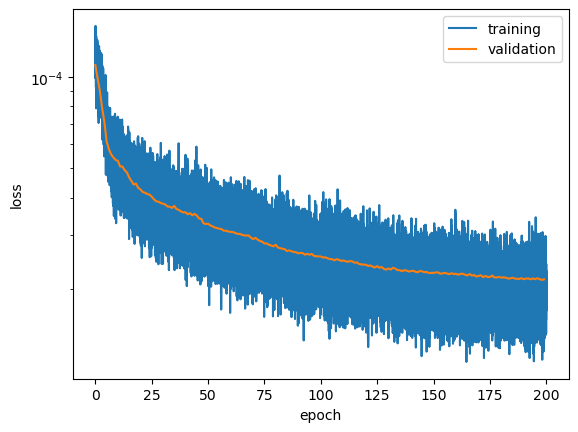

```python
# plot train and validation loss
plt.plot(np.arange(len(train_losses)) / len(trn_dataloader), train_losses, label='training')
plt.plot(np.arange(len(val_losses)), val_losses, label="validation")
plt.xlabel("epoch")
plt.ylabel("loss")
plt.yscale("log")
plt.legend()
```

We see that the validation loss decreases with the training, so there is no overtraining.

(c)

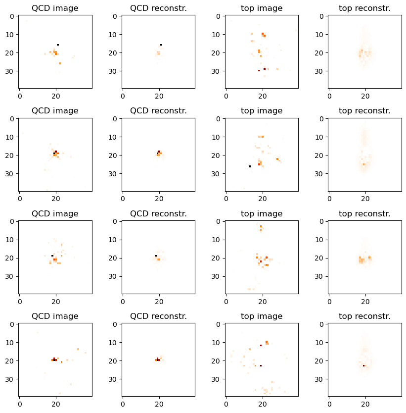

```python
# TODO: Visualize original vs reconstructed QCD and top jets

#load training data for qcd and top jets seperately
train_dataset_qcd = ae_data(z_train, y_train, qcd=True, top=False)
train_dataset_top = ae_data(z_train, y_train, qcd=False, top=True)
train_dataloader_qcd = torch.utils.data.DataLoader(train_dataset_qcd, batch_size=64, shuffle=True)
train_dataloader_top = torch.utils.data.DataLoader(train_dataset_top, batch_size=64, shuffle=True)

plt.figure(figsize=(10,10))
plt.subplots_adjust(hspace=0.4, wspace=0.4)

for i in range(4):
    ### QCD jets ###
    # get image and its reconstruction
    img = train_dataloader_qcd.dataset[i].to(device)
    out = model(img).reshape(40,40).detach().cpu().numpy()
    # plot original image
    plt.subplot(4,4,4*i+1)
    img_cpu = img.reshape(40,40).detach().cpu().numpy()
    plt.imshow(img_cpu, cmap='gist_heat_r', vmin=0, vmax=0.3)
    plt.title('QCD image')
    # plot reconstructed image
    plt.subplot(4,4,4*i+2)
    plt.imshow(out, cmap='gist_heat_r', vmin=0, vmax=0.3)
    plt.title('QCD reconstr.')

    ### top jets ###
    # get image and its reconstruction
    img = train_dataloader_top.dataset[i].to(device)
    out = model(img).reshape(40,40).detach().cpu().numpy()
    # plot original image
    plt.subplot(4,4,4*i+3)
    img_cpu = img.reshape(40,40).detach().cpu().numpy()
    plt.imshow(img_cpu, cmap='gist_heat_r', vmin=0, vmax=0.3)
    plt.title('top image')
    # plot reconstructed image
    plt.subplot(4,4,4*i+4)
    plt.imshow(out, cmap='gist_heat_r', vmin=0, vmax=0.3)
    plt.title('top reconstr.')
```

There is a reasonable reconstruction for the QCD jets while the reconstructions of the top jets are focused too much towards the center - clearly a consequence of training the autoencoder exclusively on QCD data.

(d)

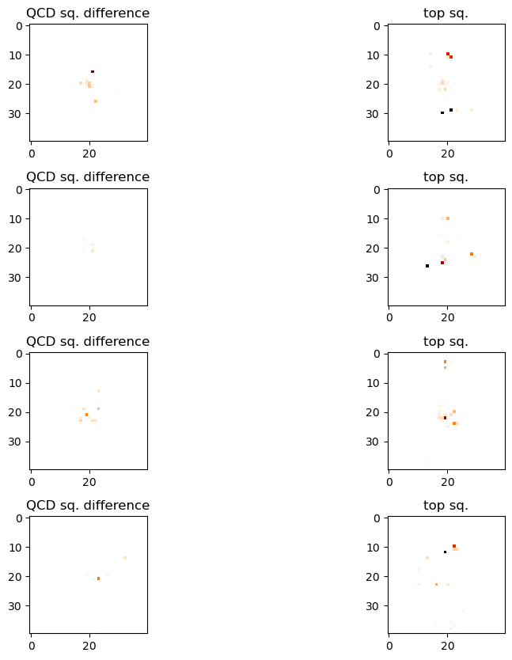

```python
# Pixel-wise sqared error

#load training data for qcd and top jets seperately
train_dataset_qcd = ae_data(z_train, y_train, qcd=True, top=False)
train_dataset_top = ae_data(z_train, y_train, qcd=False, top=True)
train_dataloader_qcd = torch.utils.data.DataLoader(train_dataset_qcd, batch_size=64, shuffle=True)
train_dataloader_top = torch.utils.data.DataLoader(train_dataset_top, batch_size=64, shuffle=True)

plt.figure(figsize=(10,10))
plt.subplots_adjust(hspace=0.4, wspace=0.4)

for i in range(4):
    ### QCD jets ###
    # get image and its reconstruction
    img = train_dataloader_qcd.dataset[i].to(device)
    out = model(img).reshape(40,40).detach().cpu().numpy()
    # plot original image
    plt.subplot(4,2,2*i+1)
    img_cpu = img.reshape(40,40).detach().cpu().numpy()
    plt.imshow((img_cpu - out)**2, cmap='gist_heat_r', vmin=0, vmax=0.02)
    plt.title('QCD sq. difference')

    ### top jets ###
    # get image and its reconstruction
    img = train_dataloader_top.dataset[i].to(device)
    out = model(img).reshape(40,40).detach().cpu().numpy()
    # plot original image
    plt.subplot(4,2,2*i+2)
    img_cpu = img.reshape(40,40).detach().cpu().numpy()
    plt.imshow((img_cpu - out)**2, cmap='gist_heat_r', vmin=0, vmax=0.02)
    plt.title('top sq.')
```

Errors are larger and lie further out for "anomalous" top images, compared to expected QCD.

The following diagram shows the image wide MSEs for the QCD trained autoencoder. By varying the threshold MSE, we can construct a ROC curve.

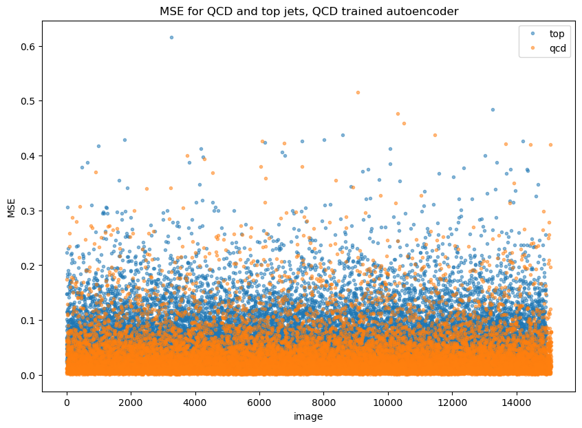

```python
# MSE for QCD and top jets
score_im = model(torch.from_numpy(z_test.astype(np.float32)).to(device)).detach().cpu().numpy().reshape(-1,40,40)
score = np.sum((z_test.reshape(score_im.shape)-score_im)**2 , axis=(1,2))
plt.figure(figsize=(10,7))
plt.plot(np.arange(len(score[y_test==1])),score[y_test==1],label="top",linestyle="None",marker=".",alpha=0.5)
plt.plot(np.arange(len(score[y_test==0])),score[y_test==0],label="qcd",linestyle="None",marker=".",alpha=0.5)
plt.legend()
plt.xlabel('image')
plt.ylabel('MSE')
plt.title('MSE for QCD and top jets, QCD trained autoencoder')
plt.show()
```

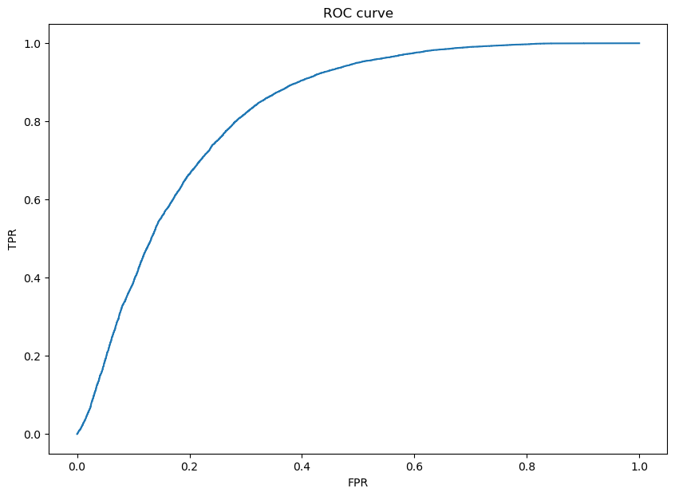

```
AUC score: 0.8220878460542878
```

```python
from sklearn.metrics import roc_curve, roc_auc_score
# TODO: Compute tpr, fpr, auc_score

fpr,tpr,threshholds = roc_curve(y_test,score)
auc = roc_auc_score(y_test,score)


# TODO: Plot ROC and SIC curve

plt.figure(figsize=(10,7))
plt.title("ROC curve")
plt.plot(fpr,tpr)
plt.xlabel("FPR")
plt.ylabel("TPR")
plt.show()

print("AUC score: "+str(auc))
```

We experimented with the last layer of the MLP autoencoder: loss and reconstructions were generally much better when there was no nonlinearity (ReLU/ Sigmoid) in the last layer.

Inspired by the observation that the sum of pixel values is always 1 in the original images (L1 norm), we tested the effect of adding a L1 normalization layer. This improved the Loss by almost an order of magnitude, compared to no final L1 layer.

Varying the bottleneck dimension had visable effect on the level of detail in the reconstructed images and the AUC in the ROC curve. For optimal results, we chose the highest bottleneck dim. of 20.

With an area under curve (AUC) of > 0.8, the MLP based autoencoder already does a good job at differenciating between expected outcomes and anomalies.

(e)

```python
# TODO: Repeat everything for CNN
class CNN_autoencoder(nn.Module):

    def __init__(self, in_ch=1, ch=4, bottleneck_dim=20, img_sz=40):
        super().__init__()
        self.conv1 = nn.Conv2d(in_ch, ch, kernel_size=5,  bias=True, stride=1, padding=2)
        self.conv2 = nn.Conv2d(ch, ch, kernel_size=5,  bias=True, stride=1, padding=2)
        self.maxpool = nn.MaxPool2d(kernel_size=2, stride=2, return_indices=True)
        self.relu = nn.ReLU()

        self.flatten = nn.Flatten()
        self.encode = nn.Linear((img_sz//2)**2 * ch, bottleneck_dim, bias=True)
        self.unflatten = nn.Unflatten(1, (ch,20,20))

        self.deconv1 = nn.ConvTranspose2d(ch, ch, kernel_size=5, bias=True, stride=1, padding=2)
        self.deconv2 = nn.ConvTranspose2d(ch, in_ch, kernel_size=5, bias=True, stride=1, padding=2)
        self.maxunpool = nn.MaxUnpool2d(kernel_size=2, stride=2)

        self.decode = nn.Linear(bottleneck_dim, (img_sz//2)**2 * ch, bias=True)

    # define forward pass
    def forward(self, x):
        # cnn encoder
        x = self.conv1(x)
        x = self.relu(x)
        x, i = self.maxpool(x)
        x = self.conv2(x)
        x = self.relu(x)

        # mlp bottleneck
        x = self.flatten(x)
        x = self.encode(x)
        x = self.relu(x)
        x = self.decode(x)
        x = self.relu(x)
        x = self.unflatten(x)

        # cnn decoder
        x = self.maxunpool(x,i)
        x = self.deconv1(x)
        x = self.relu(x)
        x = self.deconv2(x)
        return x
```

```python
def batch_loss(model, loss_fn, x):
    x = x.to(device)
    pred = model(x)
    loss = loss_fn(pred, x)
    return loss
```

```python
n_epochs = 15
bottleneck_dim = 20
channels = 32
loss_fn = nn.MSELoss()
# del model
model = CNN_autoencoder(bottleneck_dim=bottleneck_dim, ch=channels).to(device)
print(model)
total_parameters = sum(p.numel() for p in model.parameters() if p.requires_grad)
print(f"Model has {total_parameters:d} trainable parameters")

learning_rate = 1e-3
optimizer = torch.optim.Adam(model.parameters(), lr=learning_rate)
train_losses = []
val_losses = []
for epoch in range(n_epochs):
    train_losses = train_epoch(model, trn_dataloader, loss_fn, train_losses, batch_loss)

    val_losses = val_epoch(model, val_dataloader, loss_fn, val_losses, batch_loss)

    if epoch%1==0:
        print(f"{epoch + 1} / {n_epochs}")
```

```
CNN_autoencoder(
  (conv1): Conv2d(1, 32, kernel_size=(5, 5), stride=(1, 1), padding=(2, 2))
  (conv2): Conv2d(32, 32, kernel_size=(5, 5), stride=(1, 1), padding=(2, 2))
  (maxpool): MaxPool2d(kernel_size=2, stride=2, padding=0, dilation=1, ceil_mode=False)
  (relu): ReLU()
  (flatten): Flatten(start_dim=1, end_dim=-1)
  (encode): Linear(in_features=12800, out_features=20, bias=True)
  (unflatten): Unflatten(dim=1, unflattened_size=(32, 20, 20))
  (deconv1): ConvTranspose2d(32, 32, kernel_size=(5, 5), stride=(1, 1), padding=(2, 2))
  (deconv2): ConvTranspose2d(32, 1, kernel_size=(5, 5), stride=(1, 1), padding=(2, 2))
  (maxunpool): MaxUnpool2d(kernel_size=(2, 2), stride=(2, 2), padding=(0, 0))
  (decode): Linear(in_features=20, out_features=12800, bias=True)
)
Model has 577717 trainable parameters
1 / 15
2 / 15
3 / 15
4 / 15
5 / 15
6 / 15
7 / 15
8 / 15
9 / 15
10 / 15
11 / 15
12 / 15
13 / 15
14 / 15
15 / 15
```

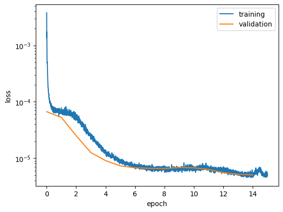

```python
# plot train and validation loss
plt.plot(np.arange(len(train_losses)) / len(trn_dataloader), train_losses, label='training')
plt.plot(np.arange(len(val_losses)), val_losses, label="validation")
plt.xlabel("epoch")
plt.ylabel("loss")
plt.yscale("log")
plt.legend()
```

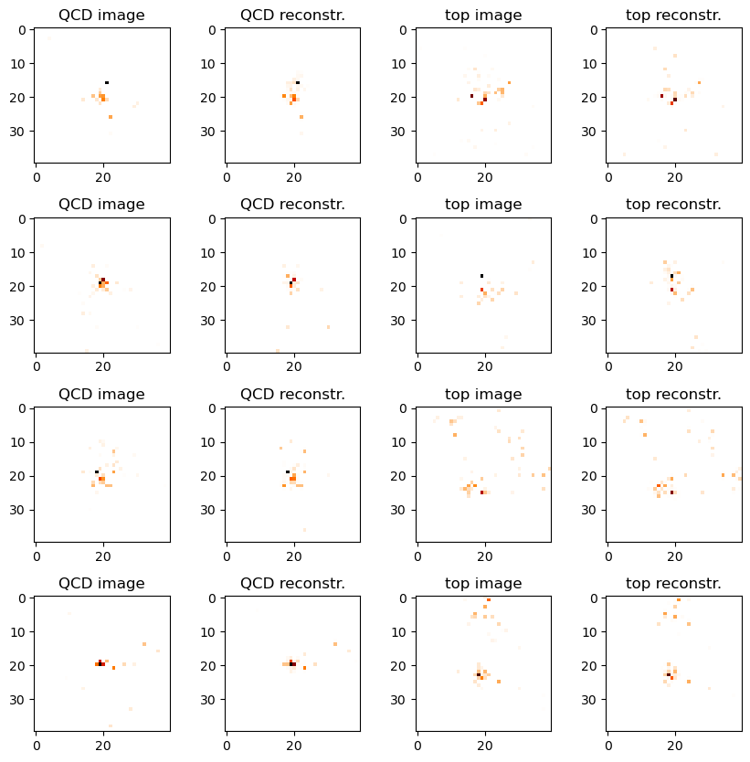

```python
# TODO: Visualize original vs reconstructed QCD and top jets

z_val_qcd = z_train[y_val==0]
z_val_top = z_train[y_val==1]


plt.figure(figsize=(10,10))
plt.subplots_adjust(hspace=0.4, wspace=0.4)

for i in range(4):
    ### QCD jets ###
    # get image and its reconstruction
    img = torch.from_numpy(z_val_qcd.astype(np.float32))[i].reshape(1,1,40,40).to(device)
    out = model(img).reshape(40,40).detach().cpu().numpy()
    # plot original image
    plt.subplot(4,4,4*i+1)
    img_cpu = img.reshape(40,40).detach().cpu().numpy()
    plt.imshow(img_cpu, cmap='gist_heat_r', vmin=0, vmax=0.3)
    plt.title('QCD image')
    # plot reconstructed image
    plt.subplot(4,4,4*i+2)
    plt.imshow(out, cmap='gist_heat_r', vmin=0, vmax=0.3)
    plt.title('QCD reconstr.')

    ### top jets ###
    # get image and its reconstruction
    img = torch.from_numpy(z_val_top.astype(np.float32))[i].reshape(1,1,40,40).to(device)
    out = model(img).reshape(40,40).detach().cpu().numpy()
    # plot original image
    plt.subplot(4,4,4*i+3)
    img_cpu = img.reshape(40,40).detach().cpu().numpy()
    plt.imshow(img_cpu, cmap='gist_heat_r', vmin=0, vmax=0.3)
    plt.title('top image')
    # plot reconstructed image
    plt.subplot(4,4,4*i+4)
    plt.imshow(out, cmap='gist_heat_r', vmin=0, vmax=0.3)
    plt.title('top reconstr.')
```

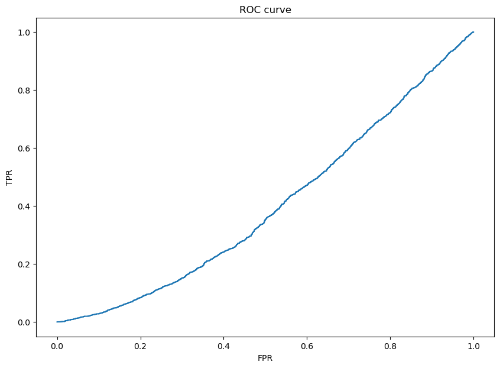

```
AUC score: 0.40131911418552146
```

```python
# model to cpu
score_im = model(torch.from_numpy(z_test[:5000].astype(np.float32)).to(device)).detach().cpu().numpy().reshape(-1,40,40)
score = np.sum((z_test[:5000].reshape(score_im.shape)-score_im)**2 , axis=(1,2))

from sklearn.metrics import roc_curve, roc_auc_score
# TODO: Compute tpr, fpr, auc_score

fpr,tpr,threshholds = roc_curve(y_test[:5000],score)
auc = roc_auc_score(y_test[:5000],score)


plt.figure(figsize=(10,7))
plt.title("ROC curve")
plt.plot(fpr,tpr)
plt.xlabel("FPR")
plt.ylabel("TPR")
plt.show()

print("AUC score: "+str(auc))
```

We can see that the CNN autoencoder trains with a smaller loss, but the ROC curve is not very good. This means that it is just generally good at reconstructing images, but not at learning them as opposed to anomalies

(f)

```python
# TODO: Repeat everything for autoencoder trained on top jets
# You can either use a MLP or a CNN
train_dataset = ae_data(z_train, y_train, qcd=False, top=True)
test_dataset = ae_data(z_test, y_test, qcd=False, top=True)
val_dataset = ae_data(z_val, y_val, qcd=False, top=True)

trn_dataloader = torch.utils.data.DataLoader(train_dataset, batch_size=64, shuffle=True )
tst_dataloader = torch.utils.data.DataLoader(test_dataset, batch_size=64, shuffle=False )
val_dataloader = torch.utils.data.DataLoader(val_dataset, batch_size=64, shuffle=False )
```

```python
n_epochs = 15
bottleneck_dim = 20
loss_fn = nn.MSELoss()

model = autoencoder(bottleneck_dim=bottleneck_dim).to(device)
print(model)
total_parameters = sum(p.numel() for p in model.parameters() if p.requires_grad)
print(f"Model has {total_parameters:d} trainable parameters")

learning_rate = 1e-3
optimizer = torch.optim.Adam(model.parameters(), lr=learning_rate)
train_losses = []
val_losses = []
for epoch in range(n_epochs):
    train_losses = train_epoch(model, trn_dataloader, loss_fn, train_losses, batch_loss)

    val_losses = val_epoch(model, val_dataloader, loss_fn, val_losses, batch_loss)

    if epoch%1==0:
        print(f"{epoch+1} / {n_epochs}")
```

```
autoencoder(
  (encoder): Sequential(
    (0): Flatten(start_dim=1, end_dim=-1)
    (1): Linear(in_features=1600, out_features=400, bias=True)
    (2): ReLU()
    (3): Linear(in_features=400, out_features=20, bias=True)
    (4): ReLU()
  )
  (decoder): Sequential(
    (0): Linear(in_features=20, out_features=400, bias=True)
    (1): ReLU()
    (2): Linear(in_features=400, out_features=1600, bias=True)
  )
)
Model has 1298420 trainable parameters
1 / 15
2 / 15
3 / 15
4 / 15
5 / 15
6 / 15
7 / 15
8 / 15
9 / 15
10 / 15
11 / 15
12 / 15
13 / 15
14 / 15
15 / 15
```

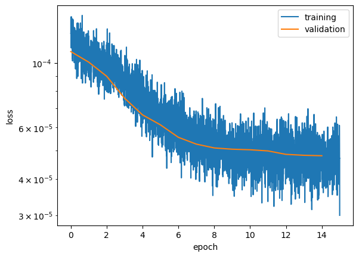

```python
# plot train and validation loss
plt.plot(np.arange(len(train_losses)) / len(trn_dataloader), train_losses, label='training')
plt.plot(np.arange(len(val_losses)), val_losses, label="validation")
plt.xlabel("epoch")
plt.ylabel("loss")
plt.yscale("log")
plt.legend()
```

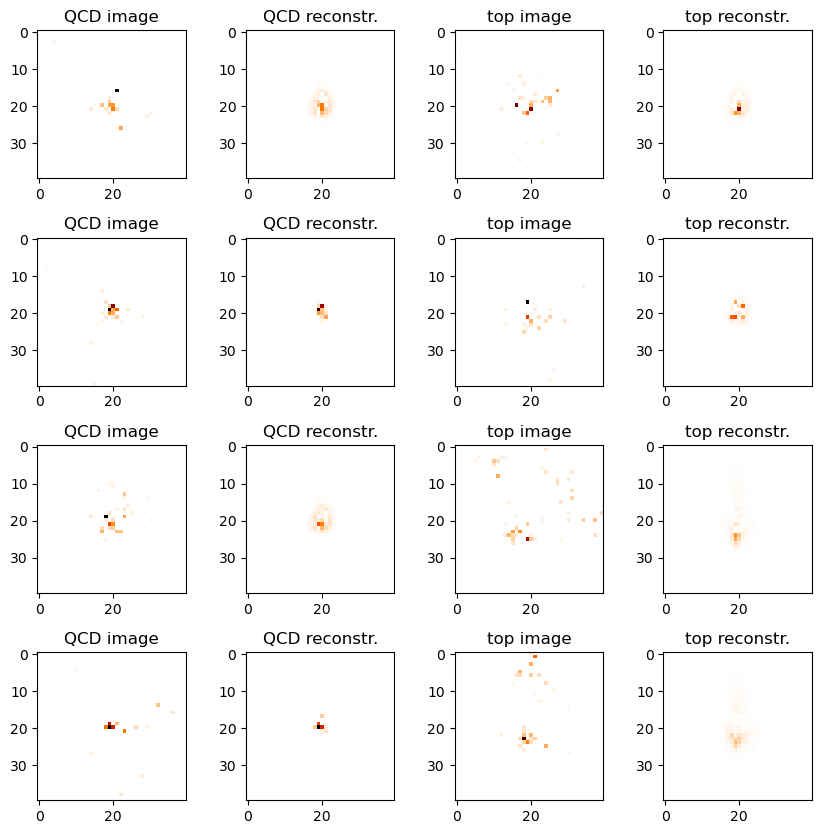

```python
# TODO: Visualize original vs reconstructed QCD and top jets

z_val_qcd = z_train[y_val==0]
z_val_top = z_train[y_val==1]


plt.figure(figsize=(10,10))
plt.subplots_adjust(hspace=0.4, wspace=0.4)

for i in range(4):
    ### QCD jets ###
    # get image and its reconstruction
    img = torch.from_numpy(z_val_qcd.astype(np.float32))[i].reshape(1,1,40,40).to(device)
    out = model(img).reshape(40,40).detach().cpu().numpy()
    # plot original image
    plt.subplot(4,4,4*i+1)
    img_cpu = img.reshape(40,40).detach().cpu().numpy()
    plt.imshow(img_cpu, cmap='gist_heat_r', vmin=0, vmax=0.3)
    plt.title('QCD image')
    # plot reconstructed image
    plt.subplot(4,4,4*i+2)
    plt.imshow(out, cmap='gist_heat_r', vmin=0, vmax=0.3)
    plt.title('QCD reconstr.')

    ### top jets ###
    # get image and its reconstruction
    img = torch.from_numpy(z_val_top.astype(np.float32))[i].reshape(1,1,40,40).to(device)
    out = model(img).reshape(40,40).detach().cpu().numpy()
    # plot original image
    plt.subplot(4,4,4*i+3)
    img_cpu = img.reshape(40,40).detach().cpu().numpy()
    plt.imshow(img_cpu, cmap='gist_heat_r', vmin=0, vmax=0.3)
    plt.title('top image')
    # plot reconstructed image
    plt.subplot(4,4,4*i+4)
    plt.imshow(out, cmap='gist_heat_r', vmin=0, vmax=0.3)
    plt.title('top reconstr.')
```

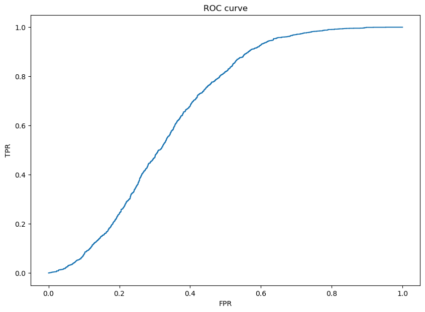

```
AUC score: 0.6685337304446686
```

```python
# TODO: Compute tpr, fpr, auc_score

score_im = model(torch.from_numpy(z_test[:5000].astype(np.float32)).to(device)).detach().cpu().numpy().reshape(-1,40,40)
score = np.sum((z_test[:5000].reshape(score_im.shape)-score_im)**2 , axis=(1,2))

from sklearn.metrics import roc_curve, roc_auc_score

fpr,tpr,threshholds = roc_curve(y_test[:5000],score)
auc = roc_auc_score(y_test[:5000],score)


plt.figure(figsize=(10,7))
plt.title("ROC curve")
plt.plot(fpr,tpr)
plt.xlabel("FPR")
plt.ylabel("TPR")
plt.show()

print("AUC score: "+str(auc))
```